# Aulas 5 - Mais sobre o R

Rafael Izbicki e Rafael Bassi Stern

16-08-2018

- Uma boa referência para a utilização do R é o *[R for data science](http://r4ds.had.co.nz/index.html)* (Garrett Grolemund e Hadley Wickham).
- Como buscar ajuda no R? Como saber quais os parâmetros de uma função?
- Google
- Stackoverflow

Utilizaremos os seguintes pacotes:

```r
library(tidyverse)
library(readxl)
```

# 1 Lendo bancos de dados

Vamos ler o conjunto Iris

Esse conjunto de dados contém informações sobre 3 espécies de flores. Foram observadas as espécies iris setosa, iris virginica e iris versicolor. Coletou-se o comprimento e largura das sépalas e pétalas (em cemtímetros) de 50 flores de cada espécie.

```r
dados <- read_excel("./data/iris.xlsx")
head(dados)
```

```
## # A tibble: 6 x 5
##   Sepal.Length Sepal.Width Petal.Length Petal.Width Species
##          <dbl>       <dbl>        <dbl>       <dbl> <chr>
## 1         5.10        3.50         1.40       0.200 setosa
## 2         4.90        3.00         1.40       0.200 setosa
## 3         4.70        3.20         1.30       0.200 setosa
## 4         4.60        3.10         1.50       0.200 setosa
## 5         5.00        3.60         1.40       0.200 setosa
## 6         5.40        3.90         1.70       0.400 setosa
```

```r
?read_excel # ajuda sobre uma função
```

*No RStudio, o símbolo de atribuição (<-) pode ser feito com o atalho alt+-*

# 2 Manipulações básicas

```r
dim(dados)
```

```
## [1] 150   5
```

```r
dados$Sepal.Length
```

```
##   [1] 5.1 4.9 4.7 4.6 5.0 5.4 4.6 5.0 4.4 4.9 5.4 4.8 4.8 4.3 5.8 5.7 5.4
##  [18] 5.1 5.7 5.1 5.4 5.1 4.6 5.1 4.8 5.0 5.0 5.2 5.2 4.7 4.8 5.4 5.2 5.5
##  [35] 4.9 5.0 5.5 4.9 4.4 5.1 5.0 4.5 4.4 5.0 5.1 4.8 5.1 4.6 5.3 5.0 7.0
##  [52] 6.4 6.9 5.5 6.5 5.7 6.3 4.9 6.6 5.2 5.0 5.9 6.0 6.1 5.6 6.7 5.6 5.8
##  [69] 6.2 5.6 5.9 6.1 6.3 6.1 6.4 6.6 6.8 6.7 6.0 5.7 5.5 5.5 5.8 6.0 5.4
##  [86] 6.0 6.7 6.3 5.6 5.5 5.5 6.1 5.8 5.0 5.6 5.7 5.7 6.2 5.1 5.7 6.3 5.8
## [103] 7.1 6.3 6.5 7.6 4.9 7.3 6.7 7.2 6.5 6.4 6.8 5.7 5.8 6.4 6.5 7.7 7.7
## [120] 6.0 6.9 5.6 7.7 6.3 6.7 7.2 6.2 6.1 6.4 7.2 7.4 7.9 6.4 6.3 6.1 7.7
## [137] 6.3 6.4 6.0 6.9 6.7 6.9 5.8 6.8 6.7 6.7 6.3 6.5 6.2 5.9
```

```r
mean(dados$Sepal.Length)
```

```
## [1] 5.843333
```

```r
median(dados$Sepal.Length)
```

```
## [1] 5.8
```

```r
var(dados$Sepal.Length)
```

```
## [1] 0.6856935
```

```r
min(dados$Sepal.Length)
```

```
## [1] 4.3
```

```r
summary(dados)
```

```
##   Sepal.Length    Sepal.Width     Petal.Length    Petal.Width
##  Min.   :4.300   Min.   :2.000   Min.   :1.000   Min.   :0.100
##  1st Qu.:5.100   1st Qu.:2.800   1st Qu.:1.600   1st Qu.:0.300
##  Median :5.800   Median :3.000   Median :4.350   Median :1.300
##  Mean   :5.843   Mean   :3.057   Mean   :3.758   Mean   :1.199
##  3rd Qu.:6.400   3rd Qu.:3.300   3rd Qu.:5.100   3rd Qu.:1.800
##  Max.   :7.900   Max.   :4.400   Max.   :6.900   Max.   :2.500
##    Species
##  Length:150
##  Class :character
##  Mode  :character
##
##
##
```

Dados é um data.frame

## 2.1 Alguns tipos de variáveis

Vetor numérico:

```r
dados$Sepal.Length
```

```
##   [1] 5.1 4.9 4.7 4.6 5.0 5.4 4.6 5.0 4.4 4.9 5.4 4.8 4.8 4.3 5.8 5.7 5.4
##  [18] 5.1 5.7 5.1 5.4 5.1 4.6 5.1 4.8 5.0 5.0 5.2 5.2 4.7 4.8 5.4 5.2 5.5
##  [35] 4.9 5.0 5.5 4.9 4.4 5.1 5.0 4.5 4.4 5.0 5.1 4.8 5.1 4.6 5.3 5.0 7.0
##  [52] 6.4 6.9 5.5 6.5 5.7 6.3 4.9 6.6 5.2 5.0 5.9 6.0 6.1 5.6 6.7 5.6 5.8
##  [69] 6.2 5.6 5.9 6.1 6.3 6.1 6.4 6.6 6.8 6.7 6.0 5.7 5.5 5.5 5.8 6.0 5.4
##  [86] 6.0 6.7 6.3 5.6 5.5 5.5 6.1 5.8 5.0 5.6 5.7 5.7 6.2 5.1 5.7 6.3 5.8
## [103] 7.1 6.3 6.5 7.6 4.9 7.3 6.7 7.2 6.5 6.4 6.8 5.7 5.8 6.4 6.5 7.7 7.7
## [120] 6.0 6.9 5.6 7.7 6.3 6.7 7.2 6.2 6.1 6.4 7.2 7.4 7.9 6.4 6.3 6.1 7.7
## [137] 6.3 6.4 6.0 6.9 6.7 6.9 5.8 6.8 6.7 6.7 6.3 6.5 6.2 5.9
```

```r
dados$Sepal.Length+1
```

```
##   [1] 6.1 5.9 5.7 5.6 6.0 6.4 5.6 6.0 5.4 5.9 6.4 5.8 5.8 5.3 6.8 6.7 6.4
##  [18] 6.1 6.7 6.1 6.4 6.1 5.6 6.1 5.8 6.0 6.0 6.2 6.2 5.7 5.8 6.4 6.2 6.5
##  [35] 5.9 6.0 6.5 5.9 5.4 6.1 6.0 5.5 5.4 6.0 6.1 5.8 6.1 5.6 6.3 6.0 8.0
##  [52] 7.4 7.9 6.5 7.5 6.7 7.3 5.9 7.6 6.2 6.0 6.9 7.0 7.1 6.6 7.7 6.6 6.8
##  [69] 7.2 6.6 6.9 7.1 7.3 7.1 7.4 7.6 7.8 7.7 7.0 6.7 6.5 6.5 6.8 7.0 6.4
##  [86] 7.0 7.7 7.3 6.6 6.5 6.5 7.1 6.8 6.0 6.6 6.7 6.7 7.2 6.1 6.7 7.3 6.8
## [103] 8.1 7.3 7.5 8.6 5.9 8.3 7.7 8.2 7.5 7.4 7.8 6.7 6.8 7.4 7.5 8.7 8.7
## [120] 7.0 7.9 6.6 8.7 7.3 7.7 8.2 7.2 7.1 7.4 8.2 8.4 8.9 7.4 7.3 7.1 8.7
## [137] 7.3 7.4 7.0 7.9 7.7 7.9 6.8 7.8 7.7 7.7 7.3 7.5 7.2 6.9
```

```r
dados$Sepal.Length+dados$Petal.Length
```

```
##   [1]  6.5  6.3  6.0  6.1  6.4  7.1  6.0  6.5  5.8  6.4  6.9  6.4  6.2  5.4
##  [15]  7.0  7.2  6.7  6.5  7.4  6.6  7.1  6.6  5.6  6.8  6.7  6.6  6.6  6.7
##  [29]  6.6  6.3  6.4  6.9  6.7  6.9  6.4  6.2  6.8  6.3  5.7  6.6  6.3  5.8
##  [43]  5.7  6.6  7.0  6.2  6.7  6.0  6.8  6.4 11.7 10.9 11.8  9.5 11.1 10.2
##  [57] 11.0  8.2 11.2  9.1  8.5 10.1 10.0 10.8  9.2 11.1 10.1  9.9 10.7  9.5
##  [71] 10.7 10.1 11.2 10.8 10.7 11.0 11.6 11.7 10.5  9.2  9.3  9.2  9.7 11.1
##  [85]  9.9 10.5 11.4 10.7  9.7  9.5  9.9 10.7  9.8  8.3  9.8  9.9  9.9 10.5
##  [99]  8.1  9.8 12.3 10.9 13.0 11.9 12.3 14.2  9.4 13.6 12.5 13.3 11.6 11.7
## [113] 12.3 10.7 10.9 11.7 12.0 14.4 14.6 11.0 12.6 10.5 14.4 11.2 12.4 13.2
## [127] 11.0 11.0 12.0 13.0 13.5 14.3 12.0 11.4 11.7 13.8 11.9 11.9 10.8 12.3
## [141] 12.3 12.0 10.9 12.7 12.4 11.9 11.3 11.7 11.6 11.0
```

```r
typeof(dados$Sepal.Length)
```

```
## [1] "double"
```

Vetor de caracteres

```r
dados$Species
```

```
##   [1] "setosa"     "setosa"     "setosa"     "setosa"     "setosa"
##   [6] "setosa"     "setosa"     "setosa"     "setosa"     "setosa"
##  [11] "setosa"     "setosa"     "setosa"     "setosa"     "setosa"
##  [16] "setosa"     "setosa"     "setosa"     "setosa"     "setosa"
##  [21] "setosa"     "setosa"     "setosa"     "setosa"     "setosa"
##  [26] "setosa"     "setosa"     "setosa"     "setosa"     "setosa"
##  [31] "setosa"     "setosa"     "setosa"     "setosa"     "setosa"
##  [36] "setosa"     "setosa"     "setosa"     "setosa"     "setosa"
##  [41] "setosa"     "setosa"     "setosa"     "setosa"     "setosa"
##  [46] "setosa"     "setosa"     "setosa"     "setosa"     "setosa"
##  [51] "versicolor" "versicolor" "versicolor" "versicolor" "versicolor"
##  [56] "versicolor" "versicolor" "versicolor" "versicolor" "versicolor"
##  [61] "versicolor" "versicolor" "versicolor" "versicolor" "versicolor"
##  [66] "versicolor" "versicolor" "versicolor" "versicolor" "versicolor"
##  [71] "versicolor" "versicolor" "versicolor" "versicolor" "versicolor"
##  [76] "versicolor" "versicolor" "versicolor" "versicolor" "versicolor"
##  [81] "versicolor" "versicolor" "versicolor" "versicolor" "versicolor"
##  [86] "versicolor" "versicolor" "versicolor" "versicolor" "versicolor"
##  [91] "versicolor" "versicolor" "versicolor" "versicolor" "versicolor"
##  [96] "versicolor" "versicolor" "versicolor" "versicolor" "versicolor"
## [101] "virginica"  "virginica"  "virginica"  "virginica"  "virginica"
## [106] "virginica"  "virginica"  "virginica"  "virginica"  "virginica"
## [111] "virginica"  "virginica"  "virginica"  "virginica"  "virginica"
## [116] "virginica"  "virginica"  "virginica"  "virginica"  "virginica"
## [121] "virginica"  "virginica"  "virginica"  "virginica"  "virginica"
## [126] "virginica"  "virginica"  "virginica"  "virginica"  "virginica"
## [131] "virginica"  "virginica"  "virginica"  "virginica"  "virginica"
## [136] "virginica"  "virginica"  "virginica"  "virginica"  "virginica"
## [141] "virginica"  "virginica"  "virginica"  "virginica"  "virginica"
## [146] "virginica"  "virginica"  "virginica"  "virginica"  "virginica"
```

```r
typeof(dados$Species)
```

```
## [1] "character"
```

Vetor lógico

```r
novo.vetor <- dados$Sepal.Length>6.5
novo.vetor
```

```
##   [1] FALSE FALSE FALSE FALSE FALSE FALSE FALSE FALSE FALSE FALSE FALSE
##  [12] FALSE FALSE FALSE FALSE FALSE FALSE FALSE FALSE FALSE FALSE FALSE
##  [23] FALSE FALSE FALSE FALSE FALSE FALSE FALSE FALSE FALSE FALSE FALSE
##  [34] FALSE FALSE FALSE FALSE FALSE FALSE FALSE FALSE FALSE FALSE FALSE
##  [45] FALSE FALSE FALSE FALSE FALSE FALSE  TRUE FALSE  TRUE FALSE FALSE
##  [56] FALSE FALSE FALSE  TRUE FALSE FALSE FALSE FALSE FALSE FALSE  TRUE
##  [67] FALSE FALSE FALSE FALSE FALSE FALSE FALSE FALSE FALSE  TRUE  TRUE
##  [78]  TRUE FALSE FALSE FALSE FALSE FALSE FALSE FALSE FALSE  TRUE FALSE
##  [89] FALSE FALSE FALSE FALSE FALSE FALSE FALSE FALSE FALSE FALSE FALSE
## [100] FALSE FALSE FALSE  TRUE FALSE FALSE  TRUE FALSE  TRUE  TRUE  TRUE
## [111] FALSE FALSE  TRUE FALSE FALSE FALSE FALSE  TRUE  TRUE FALSE  TRUE
## [122] FALSE  TRUE FALSE  TRUE  TRUE FALSE FALSE FALSE  TRUE  TRUE  TRUE
## [133] FALSE FALSE FALSE  TRUE FALSE FALSE FALSE  TRUE  TRUE  TRUE FALSE
## [144]  TRUE  TRUE  TRUE FALSE FALSE FALSE FALSE
```

```r
typeof(novo.vetor)
```

```
## [1] "logical"
```

# 3 Manipulando Dados com o dplyr

## 3.1 O operador pipe (%>%; no RStudio ctrl+shift+m)

```r
mean(dados$Sepal.Length)
```

```
## [1] 5.843333
```

Forma equivalente:

```r
dados$Sepal.Length %>% mean
```

```
## [1] 5.843333
```

```r
dados %>% names
```

```
## [1] "Sepal.Length" "Sepal.Width"  "Petal.Length" "Petal.Width"
## [5] "Species"
```

```r
dados %>% summary
```

```
##   Sepal.Length    Sepal.Width     Petal.Length    Petal.Width
##  Min.   :4.300   Min.   :2.000   Min.   :1.000   Min.   :0.100
##  1st Qu.:5.100   1st Qu.:2.800   1st Qu.:1.600   1st Qu.:0.300
##  Median :5.800   Median :3.000   Median :4.350   Median :1.300
##  Mean   :5.843   Mean   :3.057   Mean   :3.758   Mean   :1.199
##  3rd Qu.:6.400   3rd Qu.:3.300   3rd Qu.:5.100   3rd Qu.:1.800
##  Max.   :7.900   Max.   :4.400   Max.   :6.900   Max.   :2.500
##    Species
##  Length:150
##  Class :character
##  Mode  :character
##
##
##
```

As principais funções do dplyr são: select, filter, mutate, arrange, summarize e group_by

## 3.2 select

Selectiona um subconjunto das colunas

```r
dados %>% select(Sepal.Length)
```

```
## # A tibble: 150 x 1
##    Sepal.Length
##           <dbl>
##  1         5.10
##  2         4.90
##  3         4.70
##  4         4.60
##  5         5.00
##  6         5.40
##  7         4.60
##  8         5.00
##  9         4.40
## 10         4.90
## # ... with 140 more rows
```

```r
dados %>% select(Sepal.Length,Sepal.Width)
```

```
## # A tibble: 150 x 2
##    Sepal.Length Sepal.Width
##           <dbl>       <dbl>
##  1         5.10        3.50
##  2         4.90        3.00
##  3         4.70        3.20
##  4         4.60        3.10
##  5         5.00        3.60
##  6         5.40        3.90
##  7         4.60        3.40
##  8         5.00        3.40
##  9         4.40        2.90
## 10         4.90        3.10
## # ... with 140 more rows
```

```r
dados %>% select(Sepal.Length,Sepal.Width) %>% summary
```

```
##   Sepal.Length    Sepal.Width
##  Min.   :4.300   Min.   :2.000
##  1st Qu.:5.100   1st Qu.:2.800
##  Median :5.800   Median :3.000
##  Mean   :5.843   Mean   :3.057
##  3rd Qu.:6.400   3rd Qu.:3.300
##  Max.   :7.900   Max.   :4.400
```

```r
dados %>% select(Species) %>% table
```

```
## .
##     setosa versicolor  virginica
##         50         50         50
```

```r
dados %>% select(Species) %>% table %>% prop.table
```

```
## .
##     setosa versicolor  virginica
##  0.3333333  0.3333333  0.3333333
```

## 3.3 filter

Seleciona um subconjunto das linhas

```r
dados %>% filter(Species=="setosa")
```

```
## # A tibble: 50 x 5
##    Sepal.Length Sepal.Width Petal.Length Petal.Width Species
##           <dbl>       <dbl>        <dbl>       <dbl> <chr>
##  1         5.10        3.50         1.40       0.200 setosa
##  2         4.90        3.00         1.40       0.200 setosa
##  3         4.70        3.20         1.30       0.200 setosa
##  4         4.60        3.10         1.50       0.200 setosa
##  5         5.00        3.60         1.40       0.200 setosa
##  6         5.40        3.90         1.70       0.400 setosa
##  7         4.60        3.40         1.40       0.300 setosa
##  8         5.00        3.40         1.50       0.200 setosa
##  9         4.40        2.90         1.40       0.200 setosa
## 10         4.90        3.10         1.50       0.100 setosa
## # ... with 40 more rows
```

```r
dados %>% filter(Species=="setosa") %>% select(Petal.Length,Sepal.Width) %>% summary
```

```
##   Petal.Length    Sepal.Width
##  Min.   :1.000   Min.   :2.300
##  1st Qu.:1.400   1st Qu.:3.200
##  Median :1.500   Median :3.400
##  Mean   :1.462   Mean   :3.428
##  3rd Qu.:1.575   3rd Qu.:3.675
##  Max.   :1.900   Max.   :4.400
```

## 3.4 mutate

Cria novas variáveis.

```r
dados <- dados %>% mutate(SepalMaisPetalLength=Sepal.Length+Petal.Length,
                          areaSepala=Sepal.Length*Sepal.Width)

dados %>% select(SepalMaisPetalLength,areaSepala)
```

```
## # A tibble: 150 x 2
##    SepalMaisPetalLength areaSepala
##                   <dbl>      <dbl>
##  1                 6.50       17.8
##  2                 6.30       14.7
##  3                 6.00       15.0
##  4                 6.10       14.3
##  5                 6.40       18.0
##  6                 7.10       21.1
##  7                 6.00       15.6
##  8                 6.50       17.0
##  9                 5.80       12.8
## 10                 6.40       15.2
## # ... with 140 more rows
```

## 3.5 arrange

Ordena o banco

```r
dados %>% arrange(Sepal.Length)
```

```
## # A tibble: 150 x 7
##    Sepal.Length Sepal.Width Petal.Length Petal.Width Species
##           <dbl>       <dbl>        <dbl>       <dbl> <chr>
##  1         4.30        3.00         1.10       0.100 setosa
##  2         4.40        2.90         1.40       0.200 setosa
##  3         4.40        3.00         1.30       0.200 setosa
##  4         4.40        3.20         1.30       0.200 setosa
##  5         4.50        2.30         1.30       0.300 setosa
##  6         4.60        3.10         1.50       0.200 setosa
##  7         4.60        3.40         1.40       0.300 setosa
##  8         4.60        3.60         1.00       0.200 setosa
##  9         4.60        3.20         1.40       0.200 setosa
## 10         4.70        3.20         1.30       0.200 setosa
## # ... with 140 more rows, and 2 more variables:
## #   SepalMaisPetalLength <dbl>, areaSepala <dbl>
```

```r
dados <- dados %>% arrange(Species,Sepal.Length)
dados
```

```
## # A tibble: 150 x 7
##    Sepal.Length Sepal.Width Petal.Length Petal.Width Species
##           <dbl>       <dbl>        <dbl>       <dbl> <chr>
##  1         4.30        3.00         1.10       0.100 setosa
##  2         4.40        2.90         1.40       0.200 setosa
##  3         4.40        3.00         1.30       0.200 setosa
##  4         4.40        3.20         1.30       0.200 setosa
##  5         4.50        2.30         1.30       0.300 setosa
##  6         4.60        3.10         1.50       0.200 setosa
##  7         4.60        3.40         1.40       0.300 setosa
##  8         4.60        3.60         1.00       0.200 setosa
##  9         4.60        3.20         1.40       0.200 setosa
## 10         4.70        3.20         1.30       0.200 setosa
## # ... with 140 more rows, and 2 more variables:
## #   SepalMaisPetalLength <dbl>, areaSepala <dbl>
```

## 3.6 summarize

Cria resumos (i.e., calcula estatísticas) do banco

```r
dados %>% summarize(media.sepal.length=mean(Sepal.Length))
```

```
## # A tibble: 1 x 1
##   media.sepal.length
##                <dbl>
## 1               5.84
```

```r
dados %>% summarize(media.sepal.length=mean(Sepal.Length),
                    media.petal.length=mean(Petal.Length))
```

```
## # A tibble: 1 x 2
##   media.sepal.length media.petal.length
##                <dbl>              <dbl>
## 1               5.84               3.76
```

### 3.6.1 summarize_all

Idem ao summarize, mas aplica automaticamente o mesmo resumo para todas as variáveis

```r
dados %>% summarize_all(mean)
```

```
## # A tibble: 1 x 7
##   Sepal.Length Sepal.Width Petal.Length Petal.Width Species
##          <dbl>       <dbl>        <dbl>       <dbl>   <dbl>
## 1         5.84        3.06         3.76        1.20      NA
## # ... with 2 more variables: SepalMaisPetalLength <dbl>, areaSepala <dbl>
```

NA significa Not Available; não é possível fazer a média de uma variável que é composta por caracteres.

```r
dados %>% select_if(is.numeric) %>%  summarize_all(mean)
```

```
## # A tibble: 1 x 6
##   Sepal.Length Sepal.Width Petal.Length Petal.Width SepalMaisPetalLength
##          <dbl>       <dbl>        <dbl>       <dbl>                <dbl>
## 1         5.84        3.06         3.76        1.20                 9.60
## # ... with 1 more variable: areaSepala <dbl>
```

```r
dados %>% select_if(is.numeric) %>%  summarize_all(c("mean","sd"))
```

```
## # A tibble: 1 x 12
##   Sepal.Length_mean Sepal.Width_mean Petal.Length_mean Petal.Width_mean
##               <dbl>            <dbl>             <dbl>            <dbl>
## 1              5.84             3.06              3.76             1.20
## # ... with 8 more variables: SepalMaisPetalLength_mean <dbl>,
## #   areaSepala_mean <dbl>, Sepal.Length_sd <dbl>, Sepal.Width_sd <dbl>,
## #   Petal.Length_sd <dbl>, Petal.Width_sd <dbl>,
## #   SepalMaisPetalLength_sd <dbl>, areaSepala_sd <dbl>
```

```r
estatisticas <- dados %>% select_if(is.numeric) %>%
  summarize_all(funs(media=mean,desvio=sd))

estatisticas$Sepal.Length_media
```

```
## [1] 5.843333
```

```r
estatisticas %>% as.data.frame
```

```
##   Sepal.Length_media Sepal.Width_media Petal.Length_media
## 1           5.843333          3.057333              3.758
##   Petal.Width_media SepalMaisPetalLength_media areaSepala_media
## 1          1.199333                   9.601333         17.82287
##   Sepal.Length_desvio Sepal.Width_desvio Petal.Length_desvio
## 1           0.8280661          0.4358663            1.765298
##   Petal.Width_desvio SepalMaisPetalLength_desvio areaSepala_desvio
## 1          0.7622377                     2.52004          3.361854
```

```r
dados %>% summarize(media.sepal.length=mean(Sepal.Length),
                    media.petal.length=mean(Petal.Length))
```

```
## # A tibble: 1 x 2
##   media.sepal.length media.petal.length
##                <dbl>              <dbl>
## 1               5.84               3.76
```

## 3.7 group_by

```r
dados %>% group_by(Species) %>% summarize(media.sepal.length=mean(Sepal.Length),
                                          media.petal.length=mean(Petal.Length))
```

```
## # A tibble: 3 x 3
##   Species    media.sepal.length media.petal.length
##   <chr>                   <dbl>              <dbl>
## 1 setosa                   5.01               1.46
## 2 versicolor               5.94               4.26
## 3 virginica                6.59               5.55
```

```r
dados %>% group_by(Species) %>% summarize(media.sepal.length=mean(Sepal.Length),
                                          media.petal.length=mean(Petal.Length)) %>%
  arrange(desc(media.sepal.length))
```

```
## # A tibble: 3 x 3
##   Species    media.sepal.length media.petal.length
##   <chr>                   <dbl>              <dbl>
## 1 virginica                6.59               5.55
## 2 versicolor               5.94               4.26
## 3 setosa                   5.01               1.46
```

```r
mediana.petala <- median(dados$Petal.Length)

dados <- dados %>% mutate(grande=Petal.Length>mediana.petala)
dados$grande
```

```
##   [1] FALSE FALSE FALSE FALSE FALSE FALSE FALSE FALSE FALSE FALSE FALSE
##  [12] FALSE FALSE FALSE FALSE FALSE FALSE FALSE FALSE FALSE FALSE FALSE
##  [23] FALSE FALSE FALSE FALSE FALSE FALSE FALSE FALSE FALSE FALSE FALSE
##  [34] FALSE FALSE FALSE FALSE FALSE FALSE FALSE FALSE FALSE FALSE FALSE
##  [45] FALSE FALSE FALSE FALSE FALSE FALSE FALSE FALSE FALSE FALSE FALSE
##  [56]  TRUE FALSE FALSE FALSE FALSE  TRUE FALSE  TRUE FALSE FALSE FALSE
##  [67]  TRUE FALSE FALSE FALSE FALSE FALSE FALSE FALSE FALSE  TRUE FALSE
##  [78]  TRUE  TRUE  TRUE  TRUE FALSE  TRUE  TRUE  TRUE FALSE  TRUE  TRUE
##  [89]  TRUE  TRUE FALSE  TRUE  TRUE  TRUE  TRUE  TRUE  TRUE  TRUE  TRUE
## [100]  TRUE  TRUE  TRUE  TRUE  TRUE  TRUE  TRUE  TRUE  TRUE  TRUE  TRUE
## [111]  TRUE  TRUE  TRUE  TRUE  TRUE  TRUE  TRUE  TRUE  TRUE  TRUE  TRUE
## [122]  TRUE  TRUE  TRUE  TRUE  TRUE  TRUE  TRUE  TRUE  TRUE  TRUE  TRUE
## [133]  TRUE  TRUE  TRUE  TRUE  TRUE  TRUE  TRUE  TRUE  TRUE  TRUE  TRUE
## [144]  TRUE  TRUE  TRUE  TRUE  TRUE  TRUE  TRUE
```

```r
dados %>% group_by(Species,grande) %>% summarize(media.sepal.length=mean(Sepal.Length),
                                                 media.petal.length=mean(Petal.Length))
```

```
## # A tibble: 4 x 4
## # Groups:   Species [?]
##   Species    grande media.sepal.length media.petal.length
##   <chr>      <lgl>               <dbl>              <dbl>
## 1 setosa     FALSE                5.01               1.46
## 2 versicolor FALSE                5.62               3.88
## 3 versicolor TRUE                 6.26               4.64
## 4 virginica  TRUE                 6.59               5.55
```

# 4 Gráficos com o ggplot2

Vamos voltar ao conjunto iris:

```r
dados <- read_excel("./data/iris.xlsx")
```

## 4.1 Gráficos de barras

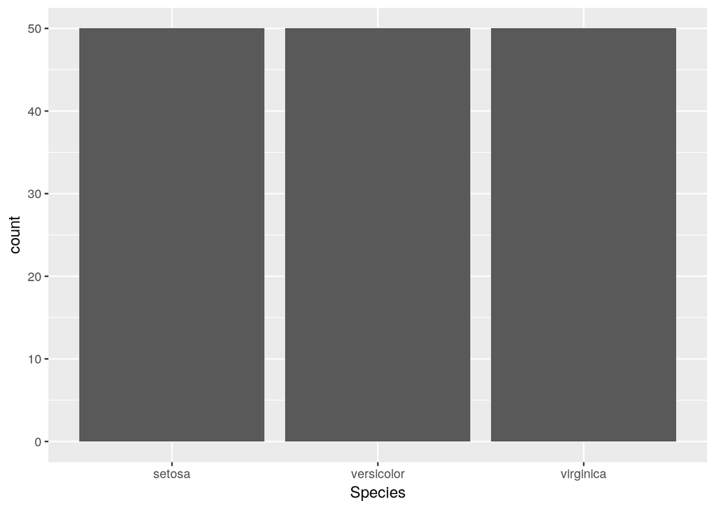

```r
ggplot(dados) + geom_bar(aes(x = Species))
```

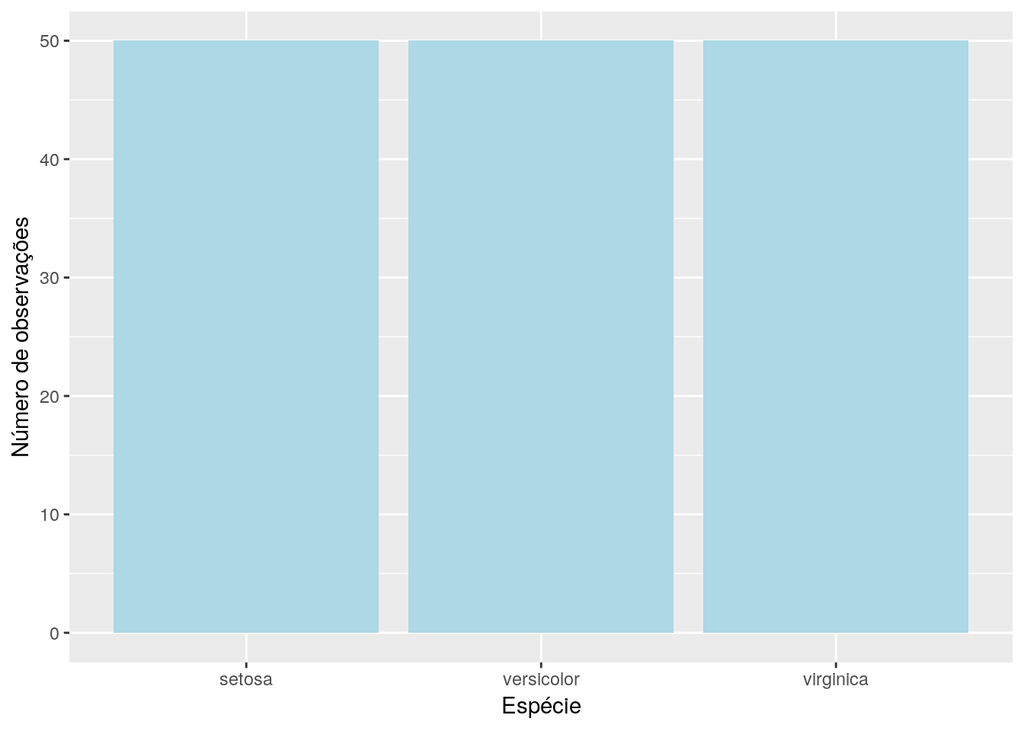

```r
ggplot(dados) + geom_bar(aes(x = Species),fill="lightblue")+xlab("Espécie")+
  ylab("Número de observações")
```

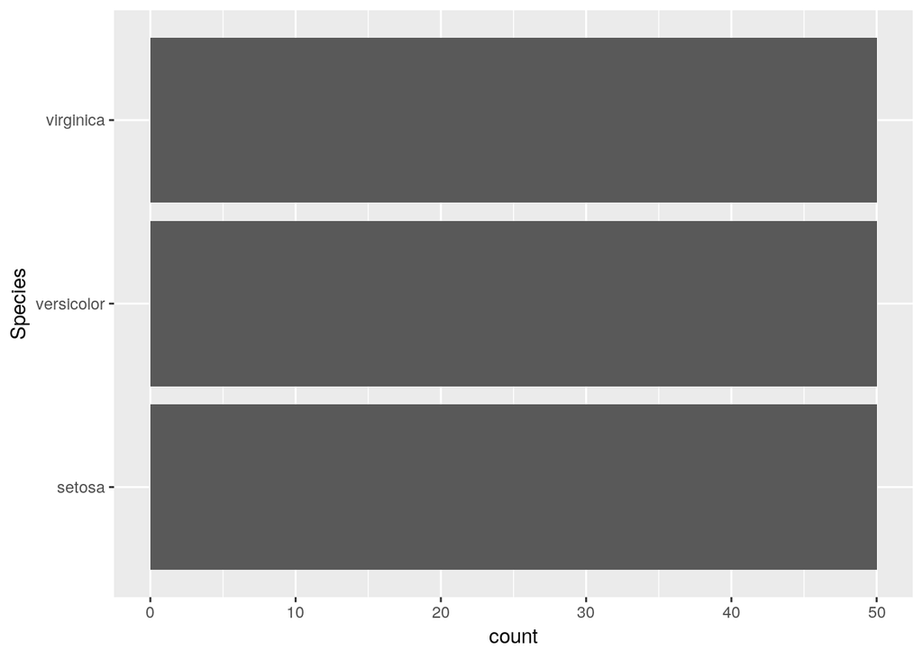

```r
ggplot(dados) + geom_bar(aes(x = Species)) + coord_flip()
```

## 4.2 Gráficos de dispersão

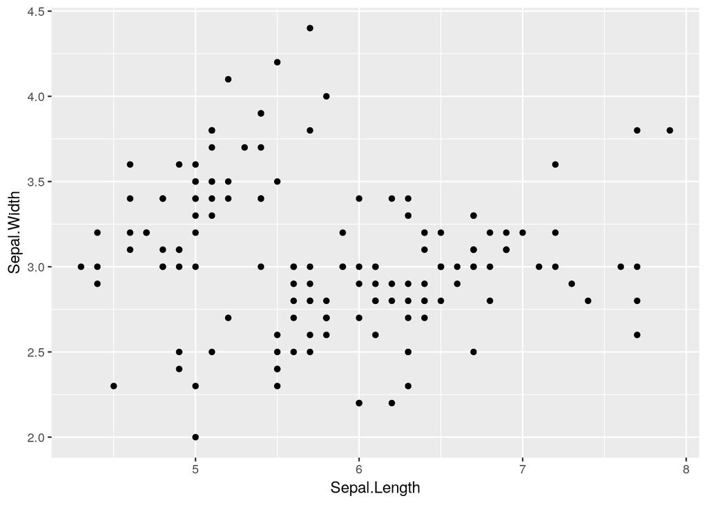

```r
ggplot(dados) +
  geom_point(aes(x=Sepal.Length, y=Sepal.Width))
```

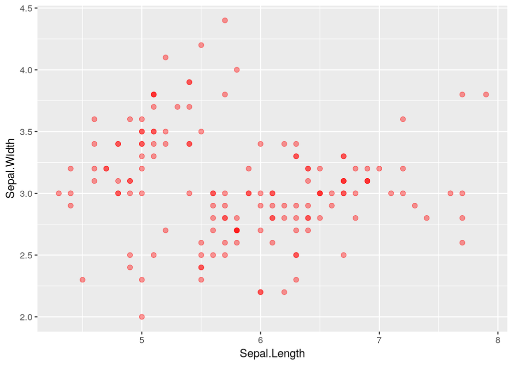

```r
ggplot(dados) +
  geom_point(aes(x=Sepal.Length, y=Sepal.Width),size=2,alpha=0.4,color="red")
```

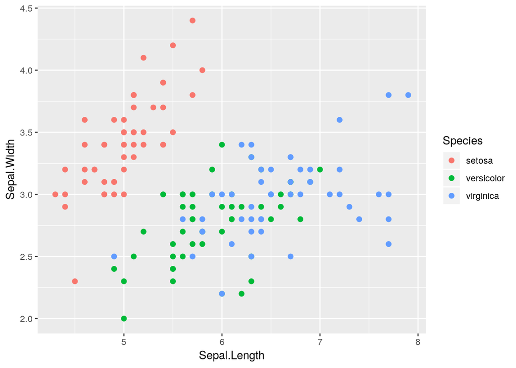

```r
ggplot(dados) +
  geom_point(aes(x=Sepal.Length, y=Sepal.Width,color = Species),size=2)
```

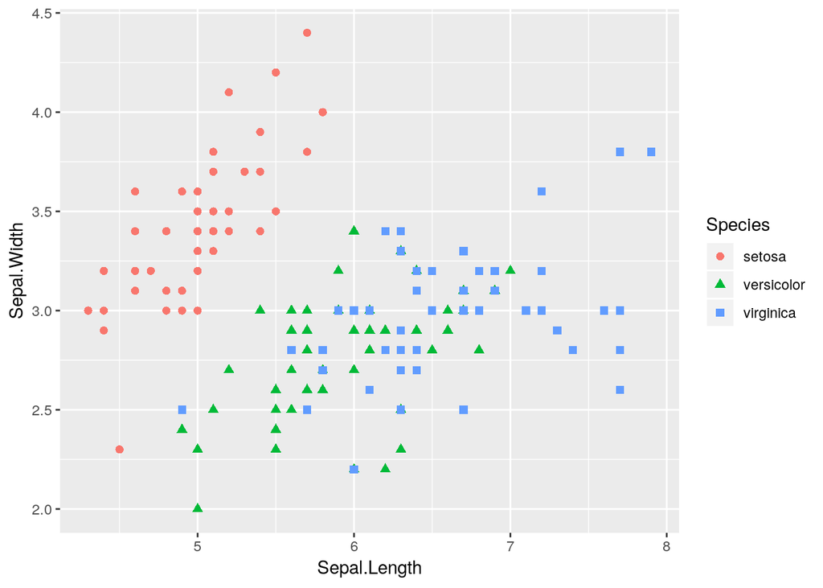

```r
ggplot(dados) +
  geom_point(aes(x=Sepal.Length, y=Sepal.Width, colour = Species,shape = Species), size = 2)
```

## 4.3 Boxplot

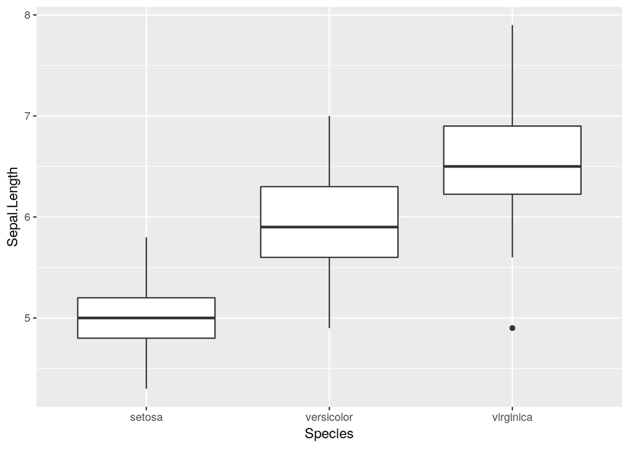

```r
ggplot(dados) + geom_boxplot(aes(x = Species, y = Sepal.Length))
```

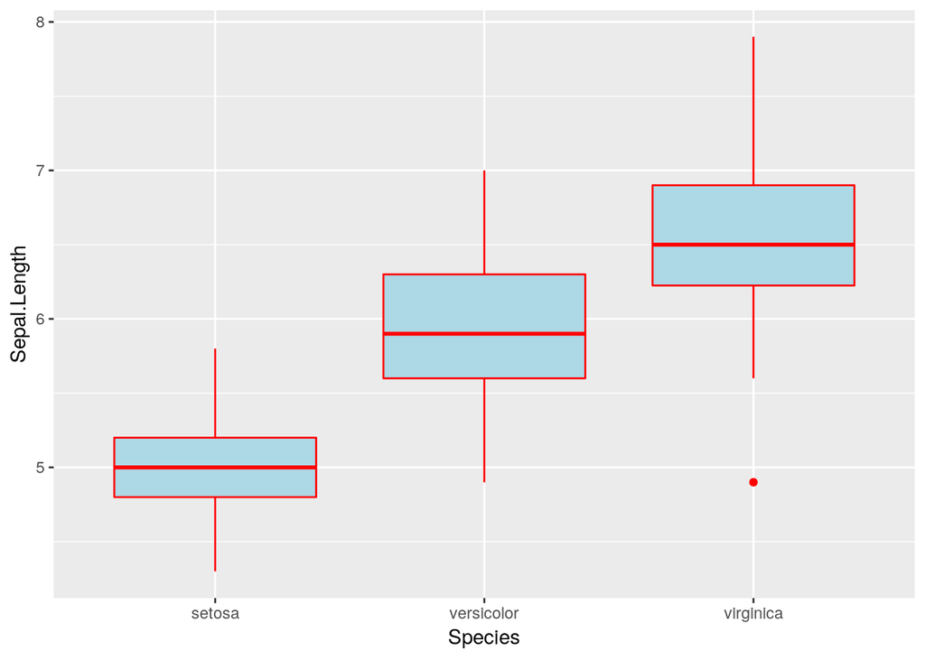

```r
ggplot(dados) +
  geom_boxplot(aes(x = Species, y = Sepal.Length),fill = "lightblue", colour= "red")
```

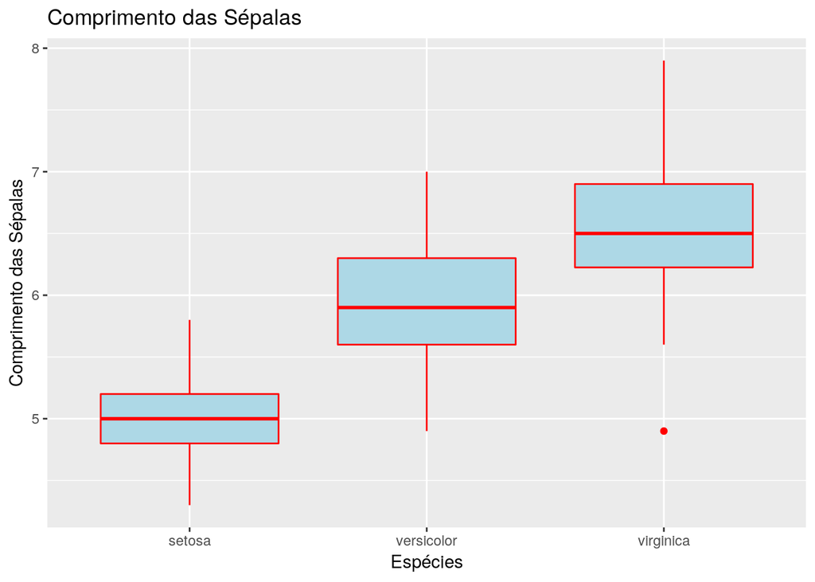

```r
ggplot(dados)  +
  geom_boxplot(aes(x = Species, y = Sepal.Length),fill = "lightblue", colour= "red") +
  xlab("Espécies") +
  ylab("Comprimento das Sépalas") +
  ggtitle("Comprimento das Sépalas")
```

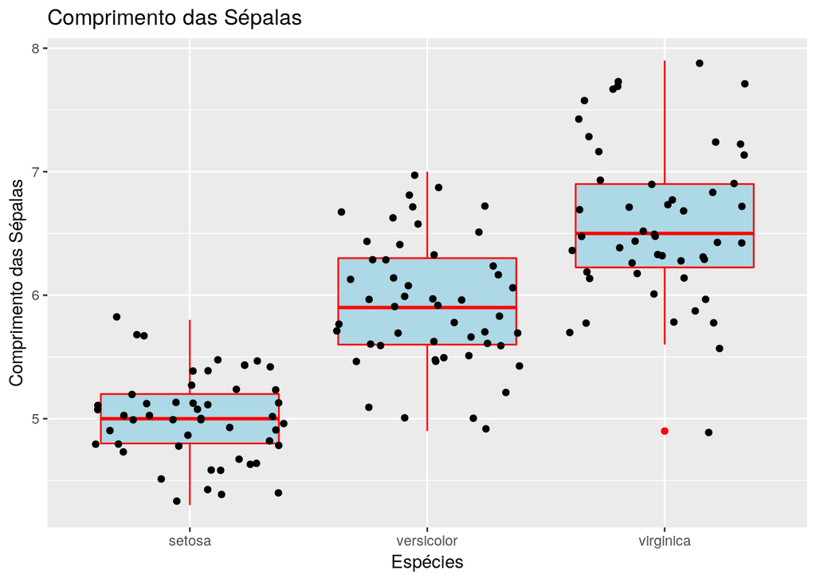

```r
ggplot(dados) +
  geom_boxplot(aes(x = Species, y = Sepal.Length),fill = "lightblue", colour= "red") +
  scale_x_discrete(name = "Espécies") +
  scale_y_continuous(name = "Comprimento das Sépalas") +
  ggtitle("Comprimento das Sépalas") + geom_jitter(aes(x = Species, y = Sepal.Length))
```

## 4.4 Histograma

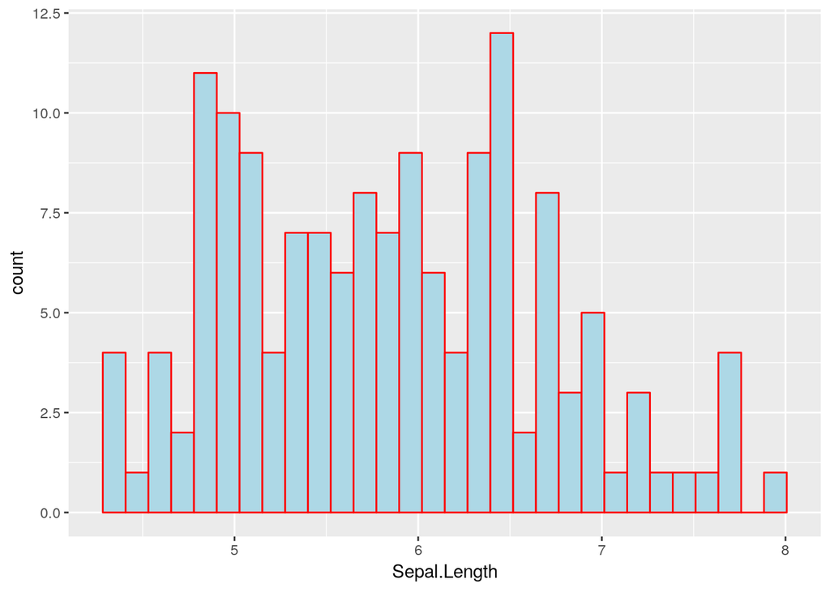

```r
ggplot(dados) +
  geom_histogram(aes(x = Sepal.Length), colour = "red", fill = "lightblue")
```

## 4.5 Facets

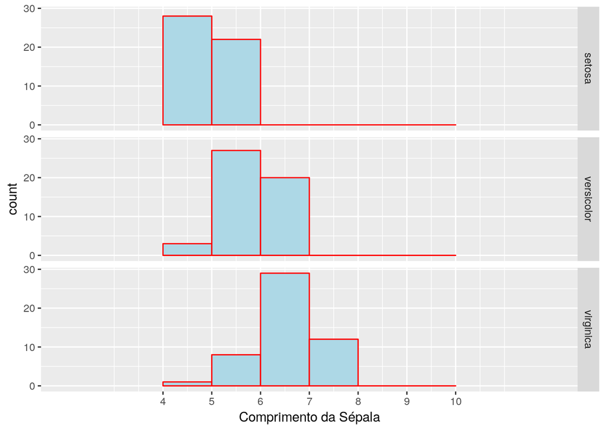

```r
ggplot(dados) +
  geom_histogram(aes(x = Sepal.Length), breaks = seq(4, 10, 1), colour = "red",
                 fill = "lightblue") +
  scale_x_continuous(name = "Comprimento da Sépala", breaks = seq(4, 10, 1),
                     limits=c(2, 12)) +
  facet_grid(Species ~ .)
```

### 4.5.1 Mudando as configurações

#### 4.5.1.1 Temas

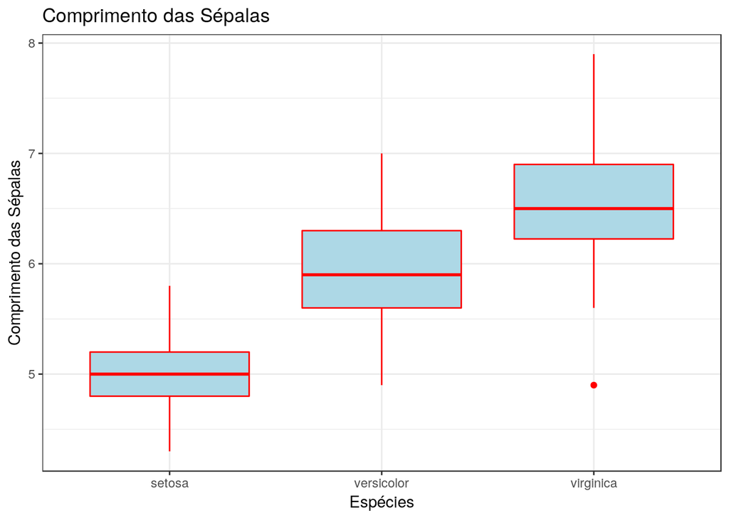

```r
ggplot(dados)  +
  geom_boxplot(aes(x = Species, y = Sepal.Length),fill = "lightblue", colour= "red") +
  xlab( "Espécies") +
  ylab( "Comprimento das Sépalas") +
  ggtitle("Comprimento das Sépalas") +  theme_bw()
```

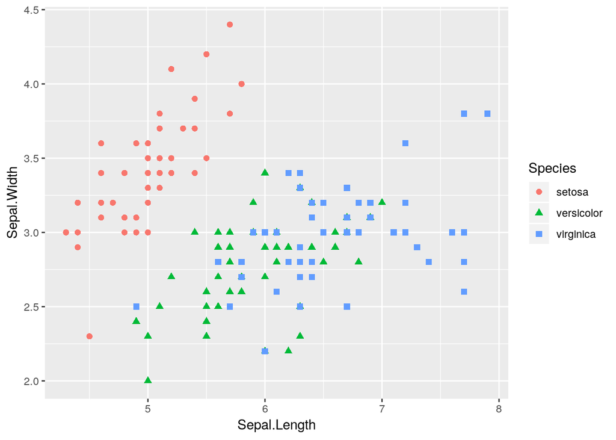

```r
ggplot(dados) +
  geom_point(aes(x=Sepal.Length, y=Sepal.Width, colour = Species,shape = Species), size = 2)
```

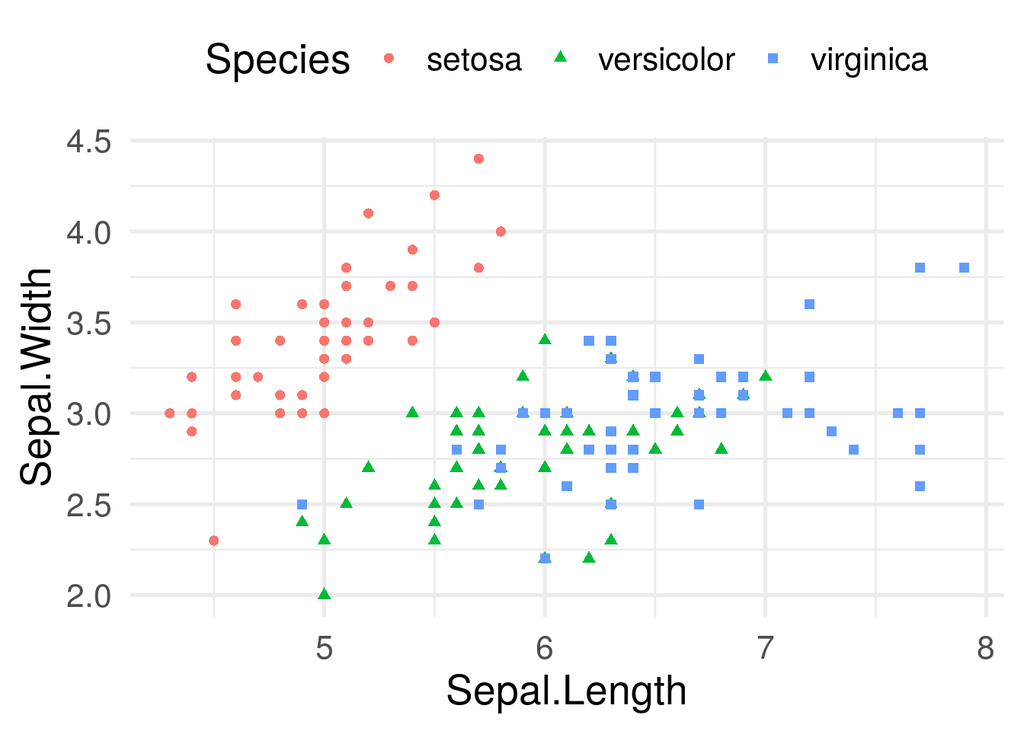

```r
theme = theme_set(theme_minimal(base_size = 20))
theme = theme_update(legend.position="top")

ggplot(dados) +
  geom_point(aes(x=Sepal.Length, y=Sepal.Width, colour = Species,shape = Species), size = 2)
```

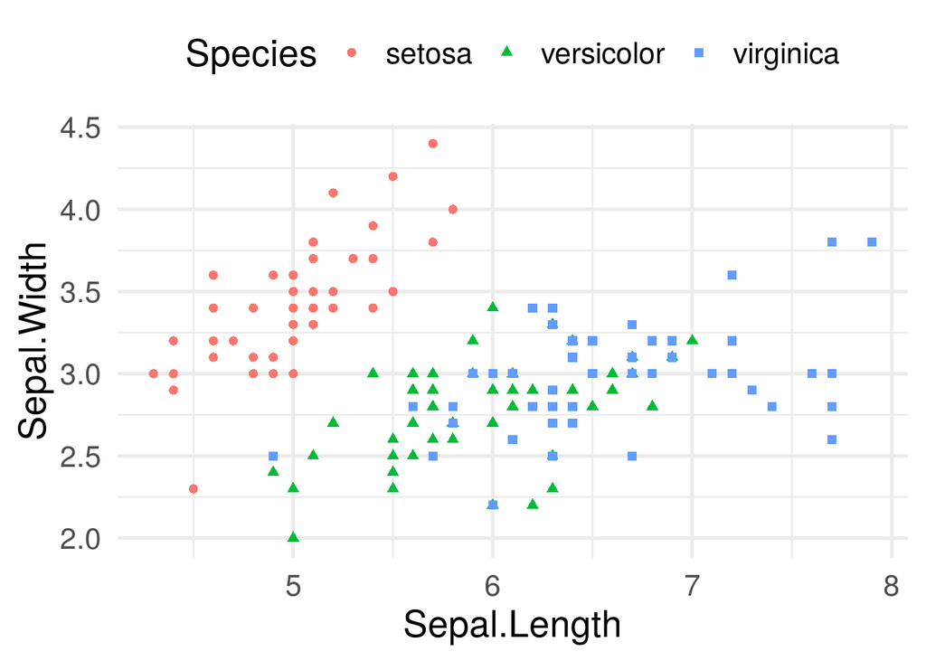

```r
ggplot(dados) +
  geom_point(aes(x=Sepal.Length, y=Sepal.Width, colour = Species,shape = Species), size = 2)
```

# 5 Exercícios

1. Considere o conjunto de dados [Bike Sharing Dataset](https://archive.ics.uci.edu/ml/datasets/Bike+Sharing+Dataset)
   1. Há mais gente usando bikes nos feriados que em dias normais?
   2. Qual a mediana do número de aluguéis por estação?
   3. Existe correlação (de Pearson) entre velocidade do vento e número de bikes alugadas?
   4. Faça um gráfico de dispersão do número de aluguéis versus a temperatura
   5. Adicione a esse gráfico uma cor para cada ponto de acordo com a estação do ano
   6. Adicione a esse gráfico uma tipo diferente de ponto para cada ponto de acordo com a estação do ano
   7. Adicione a esse gráfico uma curva que descreva a tendência dessa relação
   8. Faça novamente o gráfico do item 3, mas dessa vez separando dias de trabalho com dias de não trabalho

# 6 Referências